# E91 Performance Analyzer (via CHSH)

## Caso 2: Presenza di Eve

È prevista ora la presenza di un Eavesdropper o MITM (Eve), che si frappone nel mezzo del collegamento, misurando i qubit di Alice e Bob prima di loro stessi. Il procedimento rimane identico al precedente, con l'aggiunta delle misure di Eve.

```python
# Definiamo le misure per Eve: Alice-W
measureEA2 = QuantumCircuit(qr, cr, name='measureEA2')
measureEA2.ry(-np.pi/4,0)
measureEA2.z(0)
measureEA2.measure(qr[0],cr[2])

# Definiamo le misure per Eve: Alice-Z
measureEA3 = QuantumCircuit(qr, cr, name='measureEA3')
measureEA3.measure(qr[0],cr[2])

# Definiamo le misure per Eve: Bob-W
measureEB1 = QuantumCircuit(qr, cr, name='measureEB1')
measureEB1.ry(np.pi/4,1)
measureEB1.z(1)
measureEB1.measure(qr[1],cr[3])

# Definiamo le misure per Eve: Bob-Z
measureEB2 = QuantumCircuit(qr, cr, name='measureEB2')
measureEB2.measure(qr[1],cr[3])

# lists of measurement circuits
eveMeasurements = [measureEA2, measureEA3, measureEB1, measureEB2]
```

$$\text{Nel 50% dei casi Eve misurerà in} \; W\otimes W \; \text{e nel restante in} \; Z\otimes Z$$

```python
eveMeasurementChoices = []

for j in range(numberOfSinglets):
    if random.uniform(0, 1) <= 0.5: # nel 50% dei casi Eve misura entrambi i qubit intercettati ad Alice e Bob lungo la base W
        eveMeasurementChoices.append([0, 2])
    else: # nel 50% dei casi Eve misura entrambi i qubit intercettati ad Alice e Bob lungo la base Z
        eveMeasurementChoices.append([1, 3])
```

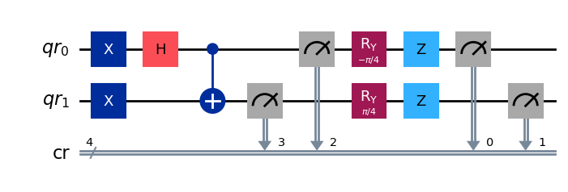

```python
circuits = [] # nuova lista di circuiti totali

for j in range(numberOfSinglets):
    circuitName = singlet.compose(eveMeasurements[eveMeasurementChoices[j][0]-1]).compose(eveMeasurements[eveMeasurementChoices[j][1]-1]).compose(aliceMeasurements[aliceMeasurementChoices[j]-1]).compose(bobMeasurements[bobMeasurementChoices[j]-1])
    # aggiungiamo ad ogni singoletto le due misure di Eve e successivamente quella di Alice e di Bob
    circuits.append(circuitName)
circuits[0].draw('mpl')
```

```python
#di nuovo iniziamo la simulazione
results=[]
for i in circuits:
    trans_circuit = transpile(i, backend=backend)
    result = backend.run(trans_circuit, shots = 1).result()
    results.append(result)
```

Si aggiungono dunque i pattern di ricerca dei possibili outcome di Eve, misurati dai primi 2 bit classici

```python
ePatterns = [
    re.compile('00..$'), # stavolta la ricerca è sui primi 2 bit classici, afferenti quindi alle misure di Eve (-1 e -1 in questo caso)
    re.compile('01..$'),
    re.compile('10..$'),
    re.compile('11..$')
]
```

```python
aliceResults, bobResults= [], []
# Risultati di Eve: gli elementi nella prima colonna afferiscono alla misura di Eve su Alice, seconda Bob
eveResults = []

for j in range(numberOfSinglets):

    res = list(results[j].get_counts().keys())[0]

    # Alice and Bob
    if abPatterns[0].search(res):
        aliceResults.append(-1)
        bobResults.append(-1)
    if abPatterns[1].search(res):
        aliceResults.append(1)
        bobResults.append(-1)
    if abPatterns[2].search(res):
        aliceResults.append(-1)
        bobResults.append(1)
    if abPatterns[3].search(res):
        aliceResults.append(1)
        bobResults.append(1)

    # Eve
    if ePatterns[0].search(res): # solito check'
        eveResults.append([-1, -1]) # verifica se entrambe le misurazioni di Alice e Bob -1,-1
    if ePatterns[1].search(res):
        eveResults.append([1, -1])
    if ePatterns[2].search(res):
        eveResults.append([-1, 1])
    if ePatterns[3].search(res):
        eveResults.append([1, 1])
```

```python
aliceKey = [] # Chiave di Alice
bobKey = [] # Chiave di Bob
eveKeys = [] # Chiave di Eve (vettore): la prima colonna afferisce a Alice, la seconda a Bob

# comparing the strings with measurement choices (b and b')
for j in range(numberOfSinglets):
    # check delle direzioni di misura
    if (aliceMeasurementChoices[j] == 2 and bobMeasurementChoices[j] == 1) or (aliceMeasurementChoices[j] == 3 and bobMeasurementChoices[j] == 2):
        aliceKey.append(aliceResults[j])
        bobKey.append(-bobResults[j])
        eveKeys.append([eveResults[j][0], -eveResults[j][1]])

keyLength = len(aliceKey)
```

```python
abKeyMismatches = 0 # No. Mismatch fra Alice e Bob
eaKeyMismatches = 0 # No. Mismatch fra Eve e Alice
ebKeyMismatches = 0 # No. Mismatch fra Eve e Bob

for j in range(keyLength):
    if aliceKey[j] != bobKey[j]:
        abKeyMismatches += 1
    if eveKeys[j][0] != aliceKey[j]:
        eaKeyMismatches += 1
    if eveKeys[j][1] != bobKey[j]:
        ebKeyMismatches += 1
```

Utile in questo caso da misurare è anche la percentuale delle chiavi (di Alice e di Bob) conosciuta da Eve

```python
#percentuali di chiave conosciuti da Eve
eaKnowledge = (keyLength - eaKeyMismatches)/keyLength # della chiave di Bob
ebKnowledge = (keyLength - ebKeyMismatches)/keyLength # della chiave di Alice
```

Si applica infine la funzione di correlazione CHSH

```python
#Applichiamo la funzione chsh
corr = chsh_corr(result)
```

### Output ricavato

```python
# Test Disuguaglianza CHSH
print('CHSH correlation value: ' + str(round(corr, 3)) + '\n')
print('relatively (CHSH_measured/CHSH_theory): ', round(corr/(-2*np.sqrt(2)), 2)*100, "%")

# Chiavi
print('Length of the key: ' + str(keyLength))
print('Number of mismatching bits: ' + str(abKeyMismatches) + '\n')

print('Eve\'s knowledge of Alice\'s key: ' + str(round(eaKnowledge * 100, 2)) + ' %')
print('Eve\'s knowledge of Bob\'s key: ' + str(round(ebKnowledge * 100, 2)) + ' %')
```

```
CHSH correlation value: -0.876

relatively (CHSH_measured/CHSH_theory):  31.0 %
Length of the key: 113
Number of mismatching bits: 37

Eve's knowledge of Alice's key: 94.69 %
Eve's knowledge of Bob's key: 91.15 %
```

Come atteso dalla presenza di fonti di interferenza il valore CHSH misurato si discosta da quello atteso, essendo il sistema entangled "collassato" dopo le misure di Eve. Risultano pertanto mismatch nella chiave, sebbene presa per basi di misura uguali.